# FEATURISATION & MODEL TUNING PROJECT

# Project Based (DOMAIN: Semiconductor manufacturing process)

CONTEXT: A complex modern semiconductor manufacturing process is normally under constant surveillance via the monitoring of signals/ variables collected from sensors and or process measurement points. However, not all of these signals are equally valuable in a specific monitoring system. The measured signals contain a combination of useful information, irrelevant information as well as noise. Engineers typically have a much larger number of signals than are actually required. If we consider each type of signal as a feature, then feature selection may be applied to identify the most relevant signals. The Process Engineers may then use these signals to determine key factors contributing to yield excursions downstream in the process. This will enable an increase in process throughput, decreased time to learning and reduce the per unit production costs. These signals can be used as features to predict the yield type. And by analysing and trying out different combinations of features, essential signals that are impacting the yield type can be identified.

PROJECT OBJECTIVE: We will build a classifier to predict the Pass/Fail yield of a particular process entity and analyse whether all the features are required to build the model or not

# 1. Import and explore the data.

```python
# Importing Libraries
import numpy as np
import pandas as pd
import matplotlib.pyplot as plt
%matplotlib inline
import seaborn as sns
import warnings
warnings.filterwarnings('ignore')
from sklearn.metrics import accuracy_score, confusion_matrix, classification_report
```

```python
# import the semiconductor csv file
sc = pd.read_csv('signal-data.csv')
sc.head()
```

|  | Time | 0 | 1 | 2 | 3 | 4 | 5 | 6 | 7 | 8 | ... | 581 | 582 | 583 | 584 | 585 | 586 | 587 | 588 | 589 | Pass/Fail |
| --- | --- | --- | --- | --- | --- | --- | --- | --- | --- | --- | --- | --- | --- | --- | --- | --- | --- | --- | --- | --- | --- |
| 0 | 2008-07-19 11:55:00 | 3030.93 | 2564.00 | 2187.7333 | 1411.1265 | 1.3602 | 100.0 | 97.6133 | 0.1242 | 1.5005 | ... | NaN | 0.5005 | 0.0118 | 0.0035 | 2.3630 | NaN | NaN | NaN | NaN | -1 |
| 1 | 2008-07-19 12:32:00 | 3095.78 | 2465.14 | 2230.4222 | 1463.6606 | 0.8294 | 100.0 | 102.3433 | 0.1247 | 1.4966 | ... | 208.2045 | 0.5019 | 0.0223 | 0.0055 | 4.4447 | 0.0096 | 0.0201 | 0.0060 | 208.2045 | -1 |
| 2 | 2008-07-19 13:17:00 | 2932.61 | 2559.94 | 2186.4111 | 1698.0172 | 1.5102 | 100.0 | 95.4878 | 0.1241 | 1.4436 | ... | 82.8602 | 0.4958 | 0.0157 | 0.0039 | 3.1745 | 0.0584 | 0.0484 | 0.0148 | 82.8602 | 1 |
| 3 | 2008-07-19 14:43:00 | 2988.72 | 2479.90 | 2199.0333 | 909.7926 | 1.3204 | 100.0 | 104.2367 | 0.1217 | 1.4882 | ... | 73.8432 | 0.4990 | 0.0103 | 0.0025 | 2.0544 | 0.0202 | 0.0149 | 0.0044 | 73.8432 | -1 |
| 4 | 2008-07-19 15:22:00 | 3032.24 | 2502.87 | 2233.3667 | 1326.5200 | 1.5334 | 100.0 | 100.3967 | 0.1235 | 1.5031 | ... | NaN | 0.4800 | 0.4766 | 0.1045 | 99.3032 | 0.0202 | 0.0149 | 0.0044 | 73.8432 | -1 |

5 rows × 592 columns

```python
sc.shape
print(f'''The given dataset has {sc.shape[0]} rows and {sc.shape[1]} columns''' )
```

```
The given dataset has 1567 rows and 592 columns
```

# 2. Data cleansing:

```python
def summary(df, pred=None):
    obs = df.shape[0]
    Types = df.dtypes
    Counts = df.apply(lambda x: x.count())
    Min = df.min()
    Max = df.max()
    Uniques = df.apply(lambda x: x.unique().shape[0])
    Nulls = df.apply(lambda x: x.isnull().sum())
    print('Data shape:', df.shape)

    if pred is None:
        cols = ['Types', 'Counts', 'Uniques', 'Nulls', 'Min', 'Max']
        str = pd.concat([Types, Counts, Uniques, Nulls, Min, Max], axis = 1, sort=True)

    str.columns = cols
    print('___________________________\nData Types:')
    print(str.Types.value_counts())
    print('___________________________')
    return str


display(summary(sc).sort_values(by='Nulls', ascending=False))
```

```
Data shape: (1567, 592)
___________________________
Data Types:
float64    590
int64        1
object       1
Name: Types, dtype: int64
___________________________
```

|  | Types | Counts | Uniques | Nulls | Min | Max |
| --- | --- | --- | --- | --- | --- | --- |
| 292 | float64 | 138 | 93 | 1429 | 0.0041 | 0.0831 |
| 158 | float64 | 138 | 139 | 1429 | 234.1 | 2505.3 |
| 157 | float64 | 138 | 129 | 1429 | 0.0118 | 0.2876 |
| 293 | float64 | 138 | 139 | 1429 | 82.3233 | 879.226 |
| 358 | float64 | 226 | 21 | 1341 | 0.0017 | 0.0047 |
| ... | ... | ... | ... | ... | ... | ... |
| 429 | float64 | 1567 | 1542 | 0 | 0.7837 | 186.616 |
| 250 | float64 | 1567 | 1566 | 0 | 21.0107 | 1119.7 |
| 251 | float64 | 1567 | 143 | 0 | 0.0003 | 0.9909 |
| 252 | float64 | 1567 | 1533 | 0 | 0.7673 | 2549.99 |
| Time | object | 1567 | 1534 | 0 | 2008-01-08 02:02:00 | 2008-12-10 18:47:00 |

592 rows × 6 columns

There are more columns with null values can be seen. will see what is the percentage of null values.

```python
def null_values(df):
    nv = pd.concat([df.isnull().sum(),df.isnull().sum()*100/df.shape[0]],axis=1).rename(columns={0:'Missing_records',1:'Percentage (%)'})
    return nv[nv.Missing_records>0].sort_values('Missing_records',ascending=False)

df_na = null_values(sc)
df_na
```

|  | Missing_records | Percentage (%) |
| --- | --- | --- |
| 292 | 1429 | 91.193363 |
| 293 | 1429 | 91.193363 |
| 157 | 1429 | 91.193363 |
| 158 | 1429 | 91.193363 |
| 358 | 1341 | 85.577537 |
| ... | ... | ... |
| 456 | 1 | 0.063816 |
| 218 | 1 | 0.063816 |
| 356 | 1 | 0.063816 |
| 457 | 1 | 0.063816 |
| 589 | 1 | 0.063816 |

538 rows × 2 columns

There are 538 objects have null values. Will see how many objects has more than 50% of null values.

```python
df_na = df_na[df_na["Percentage (%)"]>50]
df_na
```

|  | Missing_records | Percentage (%) |
| --- | --- | --- |
| 292 | 1429 | 91.193363 |
| 293 | 1429 | 91.193363 |
| 157 | 1429 | 91.193363 |
| 158 | 1429 | 91.193363 |
| 358 | 1341 | 85.577537 |
| 85 | 1341 | 85.577537 |
| 492 | 1341 | 85.577537 |
| 220 | 1341 | 85.577537 |
| 518 | 1018 | 64.964901 |
| 246 | 1018 | 64.964901 |
| 245 | 1018 | 64.964901 |
| 516 | 1018 | 64.964901 |
| 517 | 1018 | 64.964901 |
| 110 | 1018 | 64.964901 |
| 384 | 1018 | 64.964901 |
| 382 | 1018 | 64.964901 |
| 383 | 1018 | 64.964901 |
| 109 | 1018 | 64.964901 |
| 244 | 1018 | 64.964901 |
| 111 | 1018 | 64.964901 |
| 580 | 949 | 60.561583 |
| 578 | 949 | 60.561583 |
| 581 | 949 | 60.561583 |
| 579 | 949 | 60.561583 |
| 73 | 794 | 50.670070 |
| 72 | 794 | 50.670070 |
| 345 | 794 | 50.670070 |
| 346 | 794 | 50.670070 |

```python
df_na.count()
```

```
Missing_records    28
Percentage (%)     28
dtype: int64
```

There are 28 attributes have more than 50% of missing values. Let us drop these null attributes.

```python
df_na.index
```

```
Index(['292', '293', '157', '158', '358', '85', '492', '220', '518', '246',
       '245', '516', '517', '110', '384', '382', '383', '109', '244', '111',
       '580', '578', '581', '579', '73', '72', '345', '346'],
      dtype='object')
```

```python
sc.drop(columns=df_na.index,axis=1,inplace=True)
sc.shape
```

```
(1567, 564)
```

null values of more than (50%) have been dropped.

```python
sc.head()
```

|  | Time | 0 | 1 | 2 | 3 | 4 | 5 | 6 | 7 | 8 | ... | 577 | 582 | 583 | 584 | 585 | 586 | 587 | 588 | 589 | Pass/Fail |
| --- | --- | --- | --- | --- | --- | --- | --- | --- | --- | --- | --- | --- | --- | --- | --- | --- | --- | --- | --- | --- | --- |
| 0 | 2008-07-19 11:55:00 | 3030.93 | 2564.00 | 2187.7333 | 1411.1265 | 1.3602 | 100.0 | 97.6133 | 0.1242 | 1.5005 | ... | 14.9509 | 0.5005 | 0.0118 | 0.0035 | 2.3630 | NaN | NaN | NaN | NaN | -1 |
| 1 | 2008-07-19 12:32:00 | 3095.78 | 2465.14 | 2230.4222 | 1463.6606 | 0.8294 | 100.0 | 102.3433 | 0.1247 | 1.4966 | ... | 10.9003 | 0.5019 | 0.0223 | 0.0055 | 4.4447 | 0.0096 | 0.0201 | 0.0060 | 208.2045 | -1 |
| 2 | 2008-07-19 13:17:00 | 2932.61 | 2559.94 | 2186.4111 | 1698.0172 | 1.5102 | 100.0 | 95.4878 | 0.1241 | 1.4436 | ... | 9.2721 | 0.4958 | 0.0157 | 0.0039 | 3.1745 | 0.0584 | 0.0484 | 0.0148 | 82.8602 | 1 |
| 3 | 2008-07-19 14:43:00 | 2988.72 | 2479.90 | 2199.0333 | 909.7926 | 1.3204 | 100.0 | 104.2367 | 0.1217 | 1.4882 | ... | 8.5831 | 0.4990 | 0.0103 | 0.0025 | 2.0544 | 0.0202 | 0.0149 | 0.0044 | 73.8432 | -1 |
| 4 | 2008-07-19 15:22:00 | 3032.24 | 2502.87 | 2233.3667 | 1326.5200 | 1.5334 | 100.0 | 100.3967 | 0.1235 | 1.5031 | ... | 10.9698 | 0.4800 | 0.4766 | 0.1045 | 99.3032 | 0.0202 | 0.0149 | 0.0044 | 73.8432 | -1 |

5 rows × 564 columns

Missing values must be imputed

```python
# will use forward and backward method for filling missing values.
sc.fillna(method='bfill',inplace=True)
sc.fillna(method='ffill',inplace=True)
sc.head()
```

|  | Time | 0 | 1 | 2 | 3 | 4 | 5 | 6 | 7 | 8 | ... | 577 | 582 | 583 | 584 | 585 | 586 | 587 | 588 | 589 | Pass/Fail |
| --- | --- | --- | --- | --- | --- | --- | --- | --- | --- | --- | --- | --- | --- | --- | --- | --- | --- | --- | --- | --- | --- |
| 0 | 2008-07-19 11:55:00 | 3030.93 | 2564.00 | 2187.7333 | 1411.1265 | 1.3602 | 100.0 | 97.6133 | 0.1242 | 1.5005 | ... | 14.9509 | 0.5005 | 0.0118 | 0.0035 | 2.3630 | 0.0096 | 0.0201 | 0.0060 | 208.2045 | -1 |
| 1 | 2008-07-19 12:32:00 | 3095.78 | 2465.14 | 2230.4222 | 1463.6606 | 0.8294 | 100.0 | 102.3433 | 0.1247 | 1.4966 | ... | 10.9003 | 0.5019 | 0.0223 | 0.0055 | 4.4447 | 0.0096 | 0.0201 | 0.0060 | 208.2045 | -1 |
| 2 | 2008-07-19 13:17:00 | 2932.61 | 2559.94 | 2186.4111 | 1698.0172 | 1.5102 | 100.0 | 95.4878 | 0.1241 | 1.4436 | ... | 9.2721 | 0.4958 | 0.0157 | 0.0039 | 3.1745 | 0.0584 | 0.0484 | 0.0148 | 82.8602 | 1 |
| 3 | 2008-07-19 14:43:00 | 2988.72 | 2479.90 | 2199.0333 | 909.7926 | 1.3204 | 100.0 | 104.2367 | 0.1217 | 1.4882 | ... | 8.5831 | 0.4990 | 0.0103 | 0.0025 | 2.0544 | 0.0202 | 0.0149 | 0.0044 | 73.8432 | -1 |
| 4 | 2008-07-19 15:22:00 | 3032.24 | 2502.87 | 2233.3667 | 1326.5200 | 1.5334 | 100.0 | 100.3967 | 0.1235 | 1.5031 | ... | 10.9698 | 0.4800 | 0.4766 | 0.1045 | 99.3032 | 0.0202 | 0.0149 | 0.0044 | 73.8432 | -1 |

5 rows × 564 columns

```python
sc.isnull().sum()
```

```
Time         0
0            0
1            0
2            0
3            0
            ..
586          0
587          0
588          0
589          0
Pass/Fail    0
Length: 564, dtype: int64
```

All the missing values have been imputed.

```python
sc["100"].nunique()
```

```
35
```

```python
# let us check the unique values in columns:
def unique_columns(df):
    uni_list = []
    for col in df.columns:
        if df[col].nunique()==1:
            uni_list.append(col)
    return uni_list
```

```python
len(unique_columns(sc))
```

```
116
```

These 116 unique columns needs to be removed.

```python
sc.shape
```

```
(1567, 564)
```

```python
sc.drop(unique_columns(sc),axis=1,inplace=True)
sc.shape
```

```
(1567, 448)
```

Unique columns have been removed.

```python
sc.Time.dtype
```

```
dtype('O')
```

"Time" attribute is object type of datatypes. It can be removed.

```python
sc.drop("Time",axis=1,inplace=True)
sc.shape
print('The number of rows and columns in the dataframe are:',sc.shape[0], 'and',sc.shape[1],'respectively')
```

```
The number of rows and columns in the dataframe are: 1567 and 447 respectively
```

# 3. Data analysis & visualisation:

```python
unique_vals = sc['Pass/Fail'].unique()  # [0, 1, 2]
targets = [sc.loc[sc['Pass/Fail'] == val] for val in unique_vals]
```

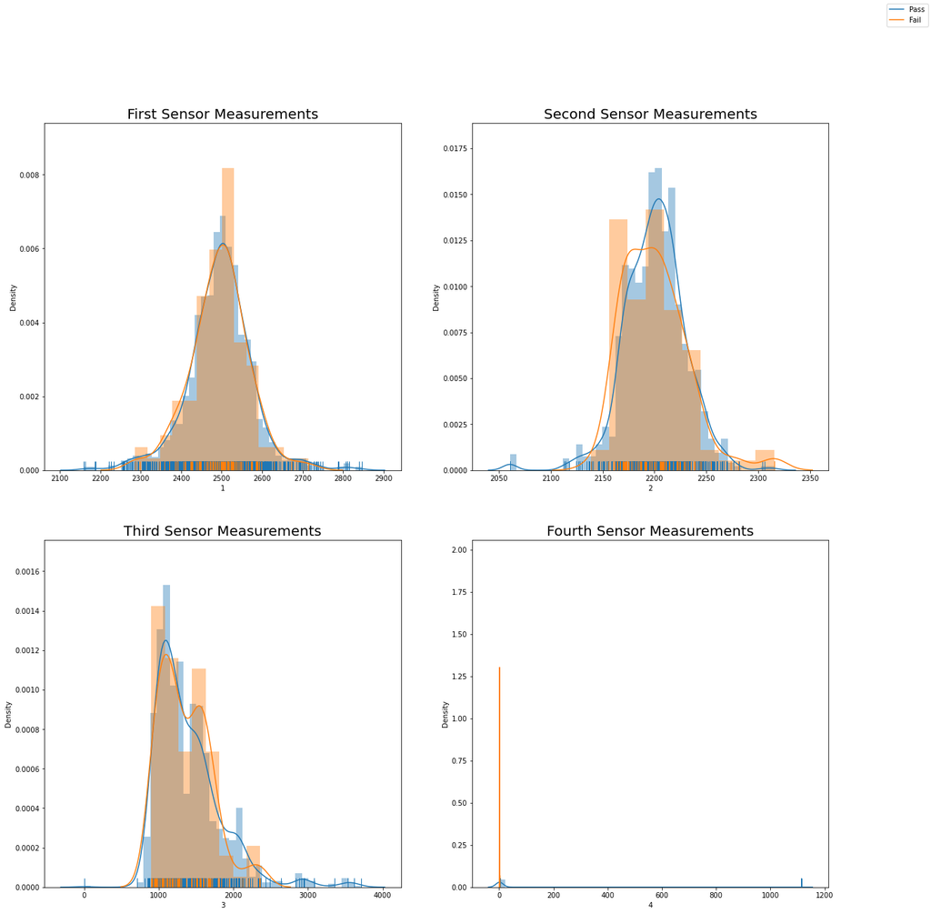

```python
fig = plt.figure(figsize=(20,20))

plt.subplot(2, 2, 1)
for target in targets:
    sns.distplot(target['1'], hist=True, rug=True)
plt.title('First Sensor Measurements', fontsize = 20)

plt.subplot(2, 2, 2)
for target in targets:
    sns.distplot(target['2'], hist=True, rug=True)
plt.title('Second Sensor Measurements', fontsize = 20)

plt.subplot(2, 2, 3)
for target in targets:
    sns.distplot(target['3'], hist=True, rug=True)
plt.title('Third Sensor Measurements', fontsize = 20)

plt.subplot(2, 2, 4)
for target in targets:
    sns.distplot(target['4'], hist=True, rug=True)
plt.title('Fourth Sensor Measurements', fontsize = 20)

#sns.add_legend()
#plt.legend()
fig.legend(labels=['Pass','Fail'])
plt.show()
```

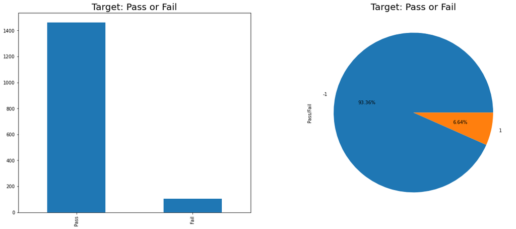

```python
# Will check the distribution of target variables
plt.figure(figsize=(20, 8))
plt.subplot(1,2,1)
plt.title('Target: Pass or Fail', fontsize = 20)
fig = sc['Pass/Fail'].value_counts().plot(kind='bar');
fig.set(xticklabels=['Pass','Fail'])
plt.subplot(1,2,2)
fig = sc['Pass/Fail'].value_counts().plot.pie(autopct='%1.2f%%');
plt.title('Target: Pass or Fail', fontsize = 20)
```

Pass percentage is 93% and Fail percentage is 7% only. There is a huge imbalance in the target column can be observed.

```python
# will check the corelation of the different attributes with respect to the target variable
sc.corr()['Pass/Fail'].sort_values()
```

```
28          -0.106255
316         -0.089390
125         -0.083560
26          -0.081481
180         -0.078612
               ...
348          0.129198
510          0.131741
103          0.151377
59           0.156159
Pass/Fail    1.000000
Name: Pass/Fail, Length: 447, dtype: float64
```

Found that no columns has a strong corelation with the target variable, maximum corelation observed is only 0.15

# 4. Data pre-processing:

```python
def remove_collinear_features(x,threshold):
    corr_matrix = x.corr()
    iters = range(len(corr_matrix.columns)-1)
    drop_cols = []

    for i in iters:
        for j in range(i+1):
            item = corr_matrix.iloc[j:(j+1),(i+1):(i+2)]
            col = item.columns
            row = item.index
            val = abs(item.values)

            if val >= threshold:
                print(col.values[0],"|",row.values[0],"|",round(val[0][0],2))
                drop_cols.append(col.values[0])

    drops = set(drop_cols)
    x = x.drop(columns = drops)
    return x
```

```python
# let us remove columns having more than 70% corelation
sc = remove_collinear_features(sc,0.7)
```

```
17 | 11 | 0.79
22 | 21 | 0.73
26 | 25 | 0.82
27 | 25 | 0.98
27 | 26 | 0.79
30 | 29 | 0.86
34 | 32 | 0.75
35 | 34 | 0.77
36 | 32 | 0.75
36 | 34 | 1.0
36 | 35 | 0.77
39 | 34 | 0.8
39 | 36 | 0.8
46 | 45 | 0.81
50 | 46 | 0.9
```

[output cut: 742 more lines]

```python
sc.shape
```

```
(1567, 205)
```

# Will build the model for unbalanced data first

# Segregate predictors vs target attributes

```python
from sklearn.model_selection import train_test_split
```

```python
# seperating target and indipendent attributes
X = sc.drop('Pass/Fail',axis=1)
y = sc['Pass/Fail']
```

```python
print('shape of X:',X.shape)
print('shape of y:',y.shape)
```

```
shape of X: (1567, 204)
shape of y: (1567,)
```

# train-test split

```python
X_train, X_test, y_train, y_test = train_test_split(X, y, stratify=y, random_state=27)
```

# Checking the shape of train and test data if they have similar statistical characteristics when compared with original data.

```python
print("Shape of X_train",X_train.shape)
print("Shape of X_test",X_test.shape)           # shape of independent variables after splitting
print("Shape of y_train",y_train.shape)
print("Shape of y_test",y_test.shape)           #shape of the Target variable after splitting

print("Shape of X",X.shape)                     # Original shape of the independent variables
print("Shape of y",y.shape)                     # Original shape of the Target variable
```

```
Shape of X_train (1175, 204)
Shape of X_test (392, 204)
Shape of y_train (1175,)
Shape of y_test (392,)
Shape of X (1567, 204)
Shape of y (1567,)
```

# Target variable distribution

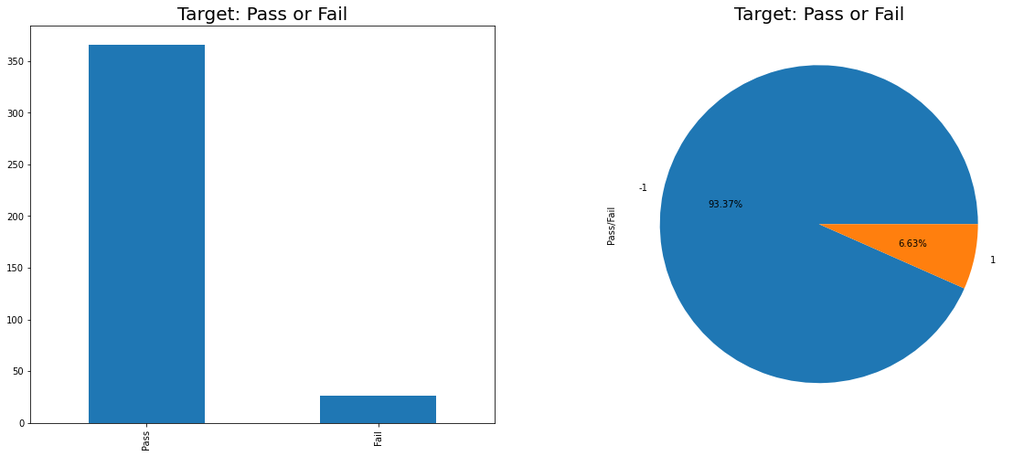

```python
# Will check the distribution of ratio of pass/fail in y_test variable.
plt.figure(figsize=(20, 8))
plt.subplot(1,2,1)
plt.title('Target: Pass or Fail', fontsize = 20)
fig = y_test.value_counts().plot(kind='bar');
fig.set(xticklabels=['Pass','Fail'])
plt.subplot(1,2,2)
fig = y_test.value_counts().plot.pie(autopct='%1.2f%%');
plt.title('Target: Pass or Fail', fontsize = 20)
```

# standardise the data

```python
# Feature scaling
from sklearn.preprocessing import StandardScaler
sc = StandardScaler()
X_train = sc.fit_transform(X_train)
X_test = sc.transform(X_test)
```

# 5. Model training, testing and tuning:

# Defining function to iterate the each model

```python
cv_acc = {}
cv_TPR = {}
cv_FPR = {}
```

```python
def plot_result(model, name:str):
    model.fit(X_train, y_train)
    y_pred = model.predict(X_test)

    # Evaluation based on a 10-fold cross-validation
    scoring = ['balanced_accuracy', 'recall_macro']
    scores = cross_val_score(model, X_test, y_test, cv=10, scoring = 'balanced_accuracy')
    cv_acc[name] = round(scores.mean(), 4)*100  # balanced accuracy
    cv_TPR[name] = (confusion_matrix(y_test, y_pred)[1][1]/confusion_matrix(y_test, y_pred)[1].sum())*100  # recall (Max)
    cv_FPR[name] = (confusion_matrix(y_test, y_pred)[0][1]/confusion_matrix(y_test, y_pred)[0].sum())*100  # fallout (Min)
    print('Average Balanced Accuracy (CV=10):', scores.mean())

    # print classification report
    print(classification_report(y_test, y_pred, zero_division=0))

    # Plot Confusion Matrix
    plot_confusion_matrix(model, X_test, y_test)
    plt.show()
```

# We will check the performance of the model one by one

# Iteration 1: With imbalnced target variable

# 1. Decision Tree

```
Average Balanced Accuracy (CV=10): 0.4741741741741742
              precision    recall  f1-score   support

          -1       0.93      0.99      0.96       366
           1       0.00      0.00      0.00        26

    accuracy                           0.93       392
   macro avg       0.47      0.50      0.48       392
weighted avg       0.87      0.93      0.90       392
```

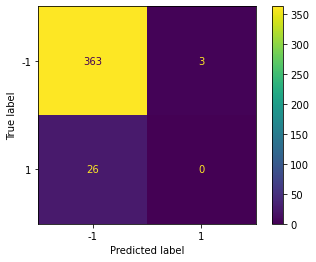

```python
from sklearn.tree import DecisionTreeClassifier, plot_tree
from sklearn.model_selection import cross_val_score
from sklearn.metrics import plot_confusion_matrix, classification_report, confusion_matrix

dt = DecisionTreeClassifier(criterion='entropy', max_depth=3)
plot_result(dt, "dt")
```

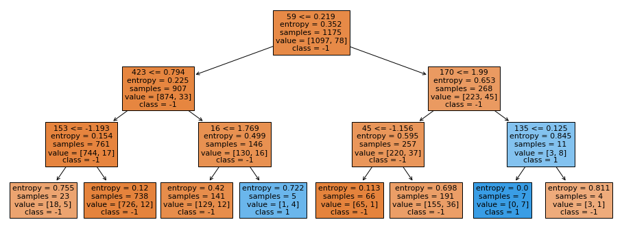

```python
# plot tree
plt.figure(figsize=(16,6))
plot_tree(dt, filled = True, class_names=["-1", "1"], feature_names=X.columns, fontsize=11);
```

```python
print(cv_acc)
print(cv_FPR)
print(cv_TPR)
```

```
{'dt': 47.42}
{'dt': 0.819672131147541}
{'dt': 0.0}
```

# 2. Logistic Regression

```
Average Balanced Accuracy (CV=10): 0.5670045045045045
              precision    recall  f1-score   support

          -1       0.95      0.96      0.95       366
           1       0.27      0.23      0.25        26

    accuracy                           0.91       392
   macro avg       0.61      0.59      0.60       392
weighted avg       0.90      0.91      0.90       392
```

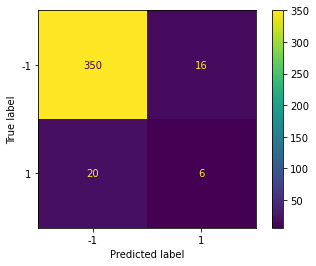

```python
from sklearn.linear_model import LogisticRegression
lr = LogisticRegression()
plot_result(lr,'lr')
```

# 3. SVM

```python
from sklearn.svm import SVC
svc = SVC(C=1.0, kernel='rbf', gamma='scale')  # default values
plot_result(svc, "svc")
```

[output not shown]

```
Average Balanced Accuracy (CV=10): 0.5
              precision    recall  f1-score   support

          -1       0.93      1.00      0.97       366
           1       0.00      0.00      0.00        26

    accuracy                           0.93       392
   macro avg       0.47      0.50      0.48       392
weighted avg       0.87      0.93      0.90       392
```

# 4. Random Forest

```python
from sklearn.ensemble import RandomForestClassifier
rfc = RandomForestClassifier(n_estimators=100, criterion='entropy', max_depth=None)
plot_result(rfc, "rfc")
```

[output not shown]

```
Average Balanced Accuracy (CV=10): 0.5
              precision    recall  f1-score   support

          -1       0.93      1.00      0.97       366
           1       0.00      0.00      0.00        26

    accuracy                           0.93       392
   macro avg       0.47      0.50      0.48       392
weighted avg       0.87      0.93      0.90       392
```

```python
def plot_feature_importances(model):
    feature_imp = pd.Series(model.feature_importances_,index=X.columns).sort_values(ascending=False)[:10]
    sns.barplot(x=feature_imp, y=feature_imp.index)
    plt.title("Feature Importance")
    plt.show()
    print(f"Top 10 Feature Importance for {str(model).split('(')[0]}\n\n",feature_imp[:10],sep='')
```

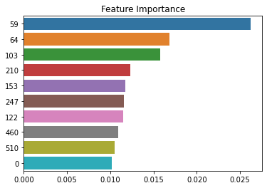

```
Top 10 Feature Importance for RandomForestClassifier

59     0.026239
64     0.016812
103    0.015773
210    0.012310
153    0.011748
247    0.011586
122    0.011489
460    0.010901
510    0.010521
0      0.010171
dtype: float64
```

```python
plot_feature_importances(rfc)
```

# 5. Gradient Boosting

```
Average Balanced Accuracy (CV=10): 0.517117117117117
              precision    recall  f1-score   support

          -1       0.94      0.92      0.93       366
           1       0.17      0.23      0.19        26

    accuracy                           0.87       392
   macro avg       0.56      0.57      0.56       392
weighted avg       0.89      0.87      0.88       392
```

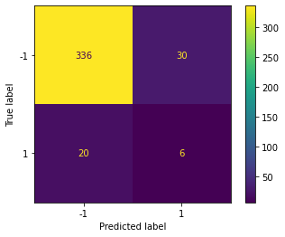

```python
from sklearn.ensemble import GradientBoostingClassifier
gb = GradientBoostingClassifier(n_estimators=100,learning_rate=1,max_depth=3,random_state=27)
plot_result(gb,'gb')
```

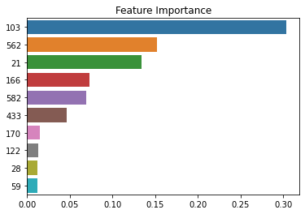

```
Top 10 Feature Importance for GradientBoostingClassifier

103    0.303697
562    0.152354
21     0.134157
166    0.073195
582    0.068818
433    0.045926
170    0.014491
122    0.013192
28     0.012052
59     0.011918
dtype: float64
```

```python
plot_feature_importances(gb)
```

# 6-Naive Bayes

```python
from sklearn.naive_bayes import GaussianNB
```

```
Average Balanced Accuracy (CV=10): 0.670045045045045
              precision    recall  f1-score   support

          -1       0.97      0.18      0.31       366
           1       0.07      0.92      0.14        26

    accuracy                           0.23       392
   macro avg       0.52      0.55      0.22       392
weighted avg       0.91      0.23      0.30       392
```

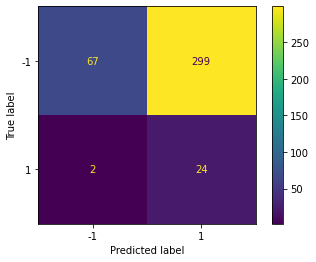

```python
nb = GaussianNB()
plot_result(nb, "nb")
```

# 7-kNN

```python
from sklearn.neighbors import KNeighborsClassifier
```

```
Average Balanced Accuracy (CV=10): 0.4945195195195195
              precision    recall  f1-score   support

          -1       0.93      0.98      0.96       366
           1       0.12      0.04      0.06        26

    accuracy                           0.92       392
   macro avg       0.53      0.51      0.51       392
weighted avg       0.88      0.92      0.90       392
```

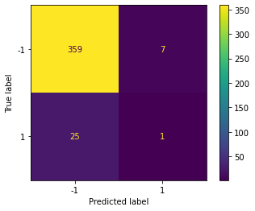

```python
knn = KNeighborsClassifier(n_neighbors=3)
plot_result(knn, "knn")
```

# 8-XG BOOST

```python
from xgboost import XGBClassifier
from sklearn.model_selection import GridSearchCV, RandomizedSearchCV, cross_val_score
```

```python
xgb = XGBClassifier(eval_metric = "logloss")
plot_result(xgb, "xgb")
```

[output not shown]

```
Average Balanced Accuracy (CV=10): 0.5
              precision    recall  f1-score   support

          -1       0.93      1.00      0.96       366
           1       0.00      0.00      0.00        26

    accuracy                           0.93       392
   macro avg       0.47      0.50      0.48       392
weighted avg       0.87      0.93      0.90       392
```

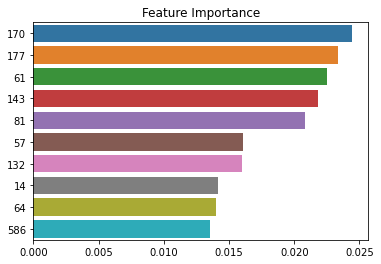

```
Top 10 Feature Importance for XGBClassifier

170    0.024440
177    0.023350
61     0.022545
143    0.021782
81     0.020816
57     0.016101
132    0.016018
14     0.014155
64     0.014039
586    0.013552
dtype: float32
```

```python
plot_feature_importances(xgb)
```

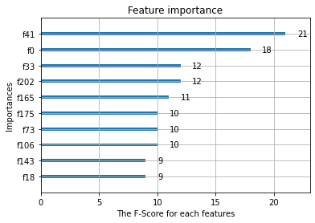

```python
from xgboost import plot_importance
plot_importance(xgb,max_num_features=10)
plt.xlabel('The F-Score for each features')
plt.ylabel('Importances')
plt.show()
```

# Evaluation (iteration 1)

```python
cv_acc
```

```
{'dt': 47.42,
 'lr': 56.699999999999996,
 'svc': 50.0,
 'rfc': 50.0,
 'gb': 51.71,
 'nb': 67.0,
 'knn': 49.45,
 'xgb': 50.0}
```

```python
cv_TPR
```

```
{'dt': 0.0,
 'lr': 23.076923076923077,
 'svc': 0.0,
 'rfc': 0.0,
 'gb': 23.076923076923077,
 'nb': 92.3076923076923,
 'knn': 3.8461538461538463,
 'xgb': 0.0}
```

```python
cv_FPR
```

```
{'dt': 0.819672131147541,
 'lr': 4.371584699453552,
 'svc': 0.0,
 'rfc': 0.0,
 'gb': 8.19672131147541,
 'nb': 81.69398907103826,
 'knn': 1.912568306010929,
 'xgb': 0.273224043715847}
```

```python
cv_FPR.values()
```

```
dict_values([0.819672131147541, 4.371584699453552, 0.0, 0.0, 8.19672131147541, 81.69398907103826, 1.912568306010929, 0.273224043715847])
```

```python
sc_ev = pd.DataFrame(data={'model':list(cv_acc.keys()),'bal_acc':list(cv_acc.values()),'recall':list(cv_TPR.values()),'fallout':list(cv_FPR.values())})
sc_ev
```

|  | model | bal_acc | recall | fallout |
| --- | --- | --- | --- | --- |
| 0 | dt | 47.42 | 0.000000 | 0.819672 |
| 1 | lr | 56.70 | 23.076923 | 4.371585 |
| 2 | svc | 50.00 | 0.000000 | 0.000000 |
| 3 | rfc | 50.00 | 0.000000 | 0.000000 |
| 4 | gb | 51.71 | 23.076923 | 8.196721 |
| 5 | nb | 67.00 | 92.307692 | 81.693989 |
| 6 | knn | 49.45 | 3.846154 | 1.912568 |
| 7 | xgb | 50.00 | 0.000000 | 0.273224 |

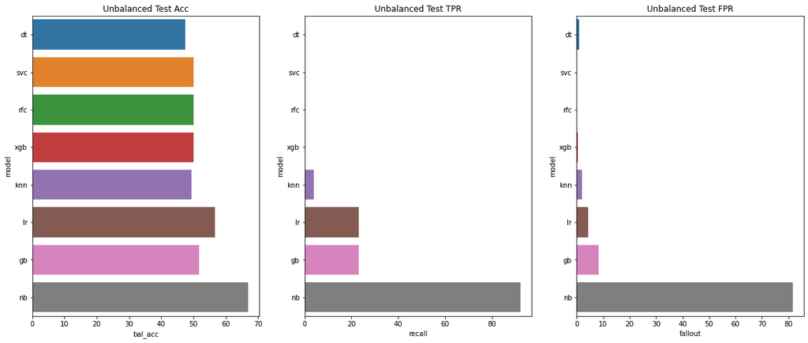

```python
fig, ax = plt.subplots(1,3,figsize=(20,8))
sns.barplot(x='bal_acc',y='model',data=sc_ev.sort_values(by='recall'),ax=ax[0])
ax[0].set_title("Unbalanced Test Acc")
sns.barplot(x="recall", y="model", data=sc_ev.sort_values(by="recall"), ax=ax[1])
ax[1].set_title("Unbalanced Test TPR")
sns.barplot(x="fallout", y="model", data=sc_ev.sort_values(by="recall"), ax=ax[2])
ax[2].set_title("Unbalanced Test FPR")
plt.show()
```

As for as accuracy and recall is considered Naive Baye's model is giving good result but fallout rate is also higher for the same

# Iteration 2: Model after target variable is balanced

```python
# Let us use Oversampling(SMOTE) technique to balance the target variable
print('y_test value count:','\n',y_test.value_counts(normalize=True))
print('\n')
print('y_train value count:','\n',y_train.value_counts(normalize=True))
```

```
y_test value count:
 -1    0.933673
 1    0.066327
Name: Pass/Fail, dtype: float64


y_train value count:
 -1    0.933617
 1    0.066383
Name: Pass/Fail, dtype: float64
```

# Fixing Target variable

```python
from imblearn.over_sampling import SMOTE
smote = SMOTE()
X_train_sm, y_train_sm = smote.fit_resample(X_train,y_train)
```

```
 1    1097
-1    1097
Name: Pass/Fail, dtype: int64
```

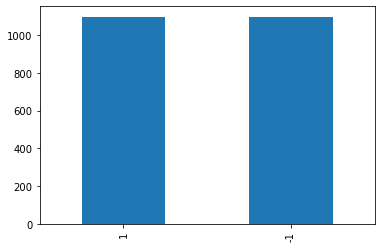

```python
print(y_train_sm.value_counts())
y_train_sm.value_counts().plot(kind='bar');
```

Target variable distribution is balanced

```python
# Let us check the shape of the independent attributes
print(X_train_sm.shape)
```

```
(2194, 204)
```

```python
cv_acc_ba = {}
cv_TPR_ba = {}
cv_FPR_ba = {}
```

```python
def plot_result_bal(model,name:str):
    model.fit(X_train_sm,y_train_sm)
    y_pred = model.predict(X_test)
#let us use 10-fold cross-validation
    scoring = ['balanced_accuracy','recall_macro']
    scores = cross_val_score(model,X_test,y_test,cv=10,scoring='balanced_accuracy')
    cv_acc_ba[name] = round(scores.mean(),4)*100
    cv_TPR_ba[name] = (confusion_matrix(y_test,y_pred)[1][1]/confusion_matrix(y_test,y_pred)[1].sum())*100
    cv_FPR_ba[name] = (confusion_matrix(y_test,y_pred)[0][1]/confusion_matrix(y_test,y_pred)[0].sum())*100
    print('Average Balanced Accuracy (CV=10):', scores.mean())
    print('\n')
    print(classification_report(y_test, y_pred, zero_division=0))
    print('\n')
    plot_confusion_matrix(model, X_test, y_test)
    plt.show()
```

# a. Decission Tree

```
Average Balanced Accuracy (CV=10): 0.47822822822822825


              precision    recall  f1-score   support

          -1       0.95      0.92      0.93       366
           1       0.19      0.27      0.23        26

    accuracy                           0.88       392
   macro avg       0.57      0.59      0.58       392
weighted avg       0.90      0.88      0.89       392
```

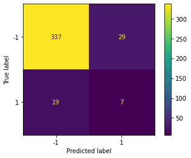

```python
dt = DecisionTreeClassifier(criterion='entropy',max_depth=3)
plot_result_bal(dt,'dt')
```

# b. Logistic Regression

```
Average Balanced Accuracy (CV=10): 0.5670045045045045


              precision    recall  f1-score   support

          -1       0.96      0.89      0.92       366
           1       0.22      0.42      0.29        26

    accuracy                           0.86       392
   macro avg       0.59      0.66      0.60       392
weighted avg       0.91      0.86      0.88       392
```

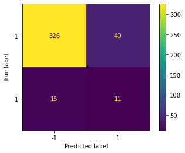

```python
lr = LogisticRegression()
plot_result_bal(lr,'lr')
```

# c. Support Vector Classifier

```python
svc = SVC()
plot_result_bal(svc,'svc')
```

[output not shown]

```
Average Balanced Accuracy (CV=10): 0.5


              precision    recall  f1-score   support

          -1       0.93      1.00      0.96       366
           1       0.00      0.00      0.00        26

    accuracy                           0.93       392
   macro avg       0.47      0.50      0.48       392
weighted avg       0.87      0.93      0.90       392
```

# d. Random Forest

```
Average Balanced Accuracy (CV=10): 0.5


              precision    recall  f1-score   support

          -1       0.94      1.00      0.97       366
           1       1.00      0.12      0.21        26

    accuracy                           0.94       392
   macro avg       0.97      0.56      0.59       392
weighted avg       0.94      0.94      0.92       392
```

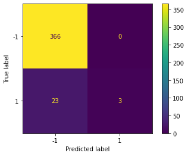

```python
rf = RandomForestClassifier()
plot_result_bal(rf,'rf')
```

# e. Gradient Boost

```
Average Balanced Accuracy (CV=10): 0.5378378378378379


              precision    recall  f1-score   support

          -1       0.94      0.96      0.95       366
           1       0.20      0.15      0.17        26

    accuracy                           0.90       392
   macro avg       0.57      0.56      0.56       392
weighted avg       0.89      0.90      0.90       392
```

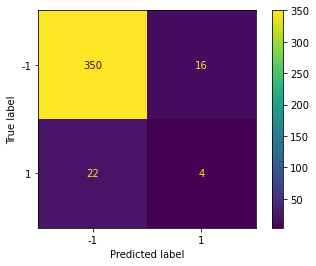

```python
gb = GradientBoostingClassifier()
plot_result_bal(gb,'gb')
```

# f. Naive Baye's

```
Average Balanced Accuracy (CV=10): 0.670045045045045


              precision    recall  f1-score   support

          -1       0.93      0.34      0.49       366
           1       0.07      0.65      0.12        26

    accuracy                           0.36       392
   macro avg       0.50      0.49      0.31       392
weighted avg       0.87      0.36      0.47       392
```

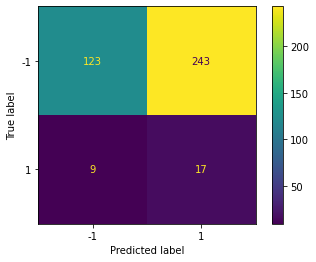

```python
nb = GaussianNB()
plot_result_bal(nb, "nb")
```

# g. KNN

```
Average Balanced Accuracy (CV=10): 0.4986486486486486


              precision    recall  f1-score   support

          -1       0.96      0.21      0.35       366
           1       0.07      0.88      0.14        26

    accuracy                           0.26       392
   macro avg       0.52      0.55      0.24       392
weighted avg       0.90      0.26      0.33       392
```

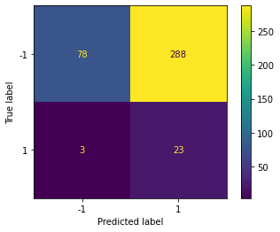

```python
knn = KNeighborsClassifier()
plot_result_bal(knn,'knn')
```

# h. XG_Boost

```
Average Balanced Accuracy (CV=10): 0.5


              precision    recall  f1-score   support

          -1       0.94      0.98      0.96       366
           1       0.30      0.12      0.17        26

    accuracy                           0.92       392
   macro avg       0.62      0.55      0.56       392
weighted avg       0.90      0.92      0.91       392
```

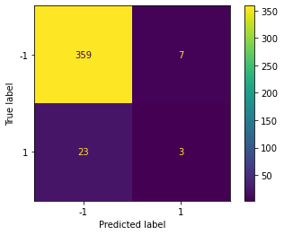

```python
xg = XGBClassifier()
plot_result_bal(xg,'xg')
```

# Evaluation (iteration 2)

```python
sc_ev_bal = pd.DataFrame(data={'model':list(cv_acc_ba.keys()),'bal_acc':list(cv_acc_ba.values()),'recall':list(cv_TPR_ba.values()),'fallout':list(cv_FPR_ba.values())})
sc_ev_bal
```

|  | model | bal_acc | recall | fallout |
| --- | --- | --- | --- | --- |
| 0 | dt | 47.82 | 26.923077 | 7.923497 |
| 1 | lr | 56.70 | 42.307692 | 10.928962 |
| 2 | svc | 50.00 | 0.000000 | 0.273224 |
| 3 | rf | 50.00 | 11.538462 | 0.000000 |
| 4 | gb | 53.78 | 15.384615 | 4.371585 |
| 5 | nb | 67.00 | 65.384615 | 66.393443 |
| 6 | knn | 49.86 | 88.461538 | 78.688525 |
| 7 | xg | 50.00 | 11.538462 | 1.912568 |

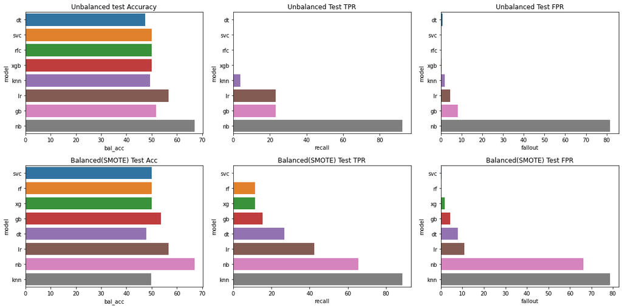

```python
fig, ax = plt.subplots(2,3, figsize=(16, 8))
sns.barplot(x="bal_acc", y="model", data=sc_ev.sort_values(by='recall'), ax=ax[0,0])
ax[0,0].set_title("Unbalanced test Accuracy")
sns.barplot(x="recall", y="model", data=sc_ev.sort_values(by='recall'), ax=ax[0,1])
ax[0,1].set_title("Unbalanced Test TPR")
sns.barplot(x="fallout", y="model", data=sc_ev.sort_values(by='recall'), ax=ax[0,2])
ax[0,2].set_title("Unbalanced Test FPR")
sns.barplot(x="bal_acc", y="model", data=sc_ev_bal.sort_values(by="recall"), ax=ax[1,0])
ax[1,0].set_title("Balanced(SMOTE) Test Acc")
sns.barplot(x="recall", y="model", data=sc_ev_bal.sort_values(by="recall"), ax=ax[1,1])
ax[1,1].set_title("Balanced(SMOTE) Test TPR")
sns.barplot(x="fallout", y="model", data=sc_ev_bal.sort_values(by="recall"), ax=ax[1,2])
ax[1,2].set_title("Balanced(SMOTE) Test FPR")
plt.tight_layout()
plt.show()
```

Naive Baye's is good in terms of accuracy and Recall score but the FPR is also higher. Gradient Boost model is yielding good compromise between accuracy, recall and Fall out for oversampled(SMOTE) target distribution.

# Iteration 3: (with SMOTE and Feature Selection Filter method)

```python
from scipy.stats import pearsonr
```

```python
sc_filtered = pd.DataFrame(X_train_sm).apply(lambda x:pd.Series(pearsonr(x,y_train_sm),index=[0,1]),axis=0).T.applymap(lambda x:np.round(x,3)).sort_values(by=1,ascending=False)
sc_filtered
```

|  | 0 | 1 |
| --- | --- | --- |
| 168 | -0.000 | 0.997 |
| 11 | 0.000 | 0.993 |
| 33 | 0.000 | 0.992 |
| 160 | 0.001 | 0.978 |
| 190 | -0.001 | 0.964 |
| ... | ... | ... |
| 125 | -0.114 | 0.000 |
| 124 | -0.087 | 0.000 |
| 123 | -0.153 | 0.000 |
| 120 | 0.118 | 0.000 |
| 102 | -0.157 | 0.000 |

204 rows × 2 columns

```python
sc_filtered = sc_filtered[sc_filtered[1] <= 0.05]
sc_filtered
```

|  | 0 | 1 |
| --- | --- | --- |
| 71 | 0.042 | 0.048 |
| 5 | -0.043 | 0.045 |
| 186 | 0.044 | 0.037 |
| 94 | -0.045 | 0.035 |
| 111 | -0.047 | 0.029 |
| ... | ... | ... |
| 125 | -0.114 | 0.000 |
| 124 | -0.087 | 0.000 |
| 123 | -0.153 | 0.000 |
| 120 | 0.118 | 0.000 |
| 102 | -0.157 | 0.000 |

127 rows × 2 columns

```python
sc_filtered.index
```

```
Int64Index([ 71,   5, 186,  94, 111, 153,  80,   0, 180,  56,
            ...
             58, 130,  59, 128, 126, 125, 124, 123, 120, 102],
           dtype='int64', length=127)
```

```python
X_train_sm_selected_filter = pd.DataFrame(X_train_sm)[sc_filtered.index]
X_test_fe = pd.DataFrame(X_test)[sc_filtered.index]
X_train_sm_selected_filter
```

|  | 71 | 5 | 186 | 94 | 111 | 153 | 80 | 0 | 180 | 56 | ... | 58 | 130 | 59 | 128 | 126 | 125 | 124 | 123 | 120 | 102 |
| --- | --- | --- | --- | --- | --- | --- | --- | --- | --- | --- | --- | --- | --- | --- | --- | --- | --- | --- | --- | --- | --- |
| 0 | 0.067663 | 1.691949 | -0.561162 | -0.172729 | -0.332588 | -0.086521 | 0.210879 | -1.006250 | -0.819795 | 0.033946 | ... | -0.229133 | -0.436329 | 0.610687 | -0.786185 | -1.208889 | 0.875517 | 1.373373 | 1.866528 | -1.987026 | -0.398392 |
| 1 | 0.627549 | 0.066395 | 0.998595 | 0.116820 | -0.734248 | -0.111413 | 0.417328 | 0.807937 | 0.645636 | -0.170510 | ... | -1.055114 | -0.859368 | -0.630966 | 2.071039 | -1.193201 | 0.085728 | 0.732889 | 0.282954 | 0.743906 | -0.509798 |
| 2 | -0.212280 | 0.191411 | -0.749584 | -0.751826 | 2.584923 | -0.098967 | 0.373865 | 0.310333 | -0.819795 | 1.976281 | ... | -0.877064 | -0.576869 | -0.236790 | -1.252949 | -0.138951 | -0.533620 | 0.027490 | 0.712950 | 0.821710 | -0.480090 |
| 3 | 0.067663 | 0.820367 | 1.350029 | -0.802923 | -0.617168 | -0.108302 | 0.330402 | -1.901181 | -0.819795 | 1.429060 | ... | -0.608533 | -0.254621 | -1.517860 | -0.299656 | -0.737535 | -1.265795 | -0.080700 | -1.549722 | -0.570123 | -0.543220 |
| 4 | 0.347606 | -1.750814 | 0.547477 | -0.326020 | 0.555477 | -0.105190 | 0.254342 | 0.671170 | -0.819795 | 1.513247 | ... | 0.010079 | 0.066207 | -2.365337 | -0.670889 | 0.779291 | 1.636499 | -1.071719 | -0.713453 | -1.311857 | -0.112449 |
| ... | ... | ... | ... | ... | ... | ... | ... | ... | ... | ... | ... | ... | ... | ... | ... | ... | ... | ... | ... | ... | ... |
| 2189 | -1.357151 | 0.859904 | 0.549988 | 0.349515 | 0.392266 | -0.102079 | 0.360002 | -0.743548 | 0.001899 | 0.783259 | ... | -0.021565 | -0.447324 | -0.236383 | -0.569018 | 0.870557 | 0.416676 | -0.384797 | -0.072845 | 0.304239 | -0.217580 |
| 2190 | 0.498660 | -0.301804 | -0.474317 | -0.437404 | -0.679904 | -0.103511 | 0.304448 | -0.701354 | -0.819795 | -0.132181 | ... | -1.392232 | 0.320584 | -0.230982 | -1.142568 | -0.625237 | 0.218823 | 0.976135 | 0.454700 | 0.156763 | -0.377178 |
| 2191 | 0.336638 | 0.683155 | -0.194426 | 0.355272 | -0.220791 | -0.110804 | 0.362999 | -1.549733 | -0.819795 | 0.534959 | ... | 0.696606 | 1.609999 | 2.179007 | 1.935102 | 1.170650 | 1.138941 | -0.787132 | 0.218128 | -1.457189 | -0.319653 |
| 2192 | 0.067663 | -0.576925 | 0.914508 | -0.066439 | -0.621033 | -0.096963 | 0.346387 | -0.001993 | -0.819795 | 0.552074 | ... | 0.098169 | 0.524345 | -0.500766 | 1.790906 | 0.853954 | -0.404617 | -0.396200 | 0.502196 | 0.156037 | -0.548272 |
| 2193 | 0.067663 | -0.161177 | 0.464000 | -0.649633 | -0.219070 | -0.107579 | 0.352133 | -0.447837 | -0.819795 | -0.128220 | ... | -0.334917 | 0.136451 | -1.345703 | 0.910197 | 0.662382 | -0.455154 | 0.075819 | 0.325529 | 0.308131 | -0.206613 |

2194 rows × 127 columns

```python
cv_acc_balance_fe = {}
cv_TPR_balance_fe = {}
cv_FPR_balance_fe = {}
```

```python
def plot_result_smoted_fe(model, name:str):
    model.fit(X_train_sm_selected_filter, y_train_sm)
    y_pred = model.predict(X_test_fe)

    # Evaluation based on a 10-fold cross-validation
    scoring = ['balanced_accuracy', 'recall_macro']
    scores = cross_val_score(model, X_test_fe, y_test, cv=10, scoring = 'balanced_accuracy')
    cv_acc_balance_fe[name] = round(scores.mean(), 4)*100  # balanced accuracy
    cv_TPR_balance_fe[name] = (confusion_matrix(y_test, y_pred)[1][1]/confusion_matrix(y_test, y_pred)[1].sum())*100  # recall (maximize)
    cv_FPR_balance_fe[name] = (confusion_matrix(y_test, y_pred)[0][1]/confusion_matrix(y_test, y_pred)[0].sum())*100  # fallout (minimize)
    print('Average Balanced Accuracy (CV=10):', scores.mean())

    # print classification report
    print(classification_report(y_test, y_pred, zero_division=0))

    # Plot Confusion Matrix
    plt.figure(figsize=(3,3))
    plot_confusion_matrix(model, X_test_fe, y_test)
    plt.show()
```

# a.Decision Tree

```
Average Balanced Accuracy (CV=10): 0.5016516516516517
              precision    recall  f1-score   support

          -1       0.95      0.92      0.93       366
           1       0.18      0.27      0.22        26

    accuracy                           0.87       392
   macro avg       0.57      0.59      0.57       392
weighted avg       0.90      0.87      0.88       392
```

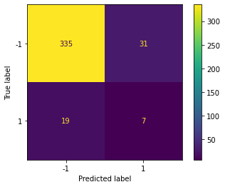

```python
dt = DecisionTreeClassifier(criterion='entropy', max_depth=3)

plot_result_smoted_fe(dt, "dt")
```

# b. Logistic regression

```
Average Balanced Accuracy (CV=10): 0.5823573573573573
              precision    recall  f1-score   support

          -1       0.96      0.83      0.89       366
           1       0.18      0.50      0.26        26

    accuracy                           0.81       392
   macro avg       0.57      0.67      0.58       392
weighted avg       0.91      0.81      0.85       392
```

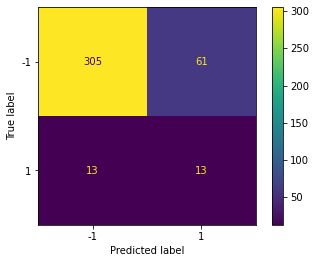

```python
lr = LogisticRegression()

plot_result_smoted_fe(lr, "lr")
```

# c. Support Vector Classifier

```
Average Balanced Accuracy (CV=10): 0.5
              precision    recall  f1-score   support

          -1       0.94      0.99      0.96       366
           1       0.33      0.04      0.07        26

    accuracy                           0.93       392
   macro avg       0.63      0.52      0.52       392
weighted avg       0.90      0.93      0.90       392
```

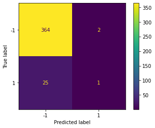

```python
svc = SVC() # default Werte
plot_result_smoted_fe(svc, "svc")
```

# d. Random Forest

```
Average Balanced Accuracy (CV=10): 0.5
              precision    recall  f1-score   support

          -1       0.94      0.99      0.96       366
           1       0.29      0.08      0.12        26

    accuracy                           0.93       392
   macro avg       0.61      0.53      0.54       392
weighted avg       0.89      0.93      0.91       392
```

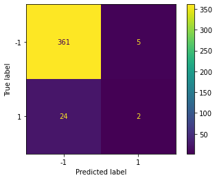

```python
rf = RandomForestClassifier()
plot_result_smoted_fe(rf, "rf")
```

# e. Gradient Boost

```
Average Balanced Accuracy (CV=10): 0.5224474474474474
              precision    recall  f1-score   support

          -1       0.94      0.95      0.94       366
           1       0.11      0.08      0.09        26

    accuracy                           0.90       392
   macro avg       0.52      0.52      0.52       392
weighted avg       0.88      0.90      0.89       392
```

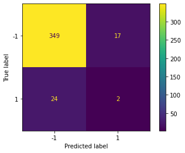

```python
gb = GradientBoostingClassifier(random_state=27)
plot_result_smoted_fe(gb, "gb")
```

# f. Naive Baye's

```
Average Balanced Accuracy (CV=10): 0.6547297297297298
              precision    recall  f1-score   support

          -1       0.95      0.76      0.84       366
           1       0.10      0.38      0.16        26

    accuracy                           0.73       392
   macro avg       0.52      0.57      0.50       392
weighted avg       0.89      0.73      0.80       392
```

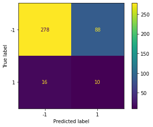

```python
nb = GaussianNB()
plot_result_smoted_fe(nb, "nb")
```

# g. KNN

```
Average Balanced Accuracy (CV=10): 0.49587087087087084
              precision    recall  f1-score   support

          -1       0.95      0.40      0.56       366
           1       0.08      0.73      0.14        26

    accuracy                           0.42       392
   macro avg       0.52      0.56      0.35       392
weighted avg       0.90      0.42      0.53       392
```

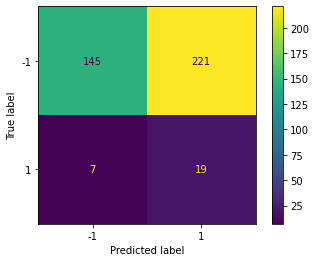

```python
knn = KNeighborsClassifier(n_neighbors=3)
plot_result_smoted_fe(knn, "knn")
```

# h. XG Boost

```
Average Balanced Accuracy (CV=10): 0.525
              precision    recall  f1-score   support

          -1       0.94      0.98      0.96       366
           1       0.25      0.08      0.12        26

    accuracy                           0.92       392
   macro avg       0.59      0.53      0.54       392
weighted avg       0.89      0.92      0.90       392
```

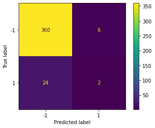

```python
xg = XGBClassifier(random_state=27)
plot_result_smoted_fe(xg, "xg");
```

# Evaluation (iteration 3)

```python
sc_eval_smote_fe = pd.DataFrame(data={'model': list(cv_acc_balance_fe.keys()), 'bal_acc': list(cv_acc_balance_fe.values()), 'recall': list(cv_TPR_balance_fe.values()), 'fallout':list(cv_FPR_balance_fe.values())})
sc_eval_smote_fe
```

|  | model | bal_acc | recall | fallout |
| --- | --- | --- | --- | --- |
| 0 | dt | 50.17 | 26.923077 | 8.469945 |
| 1 | lr | 58.24 | 50.000000 | 16.666667 |
| 2 | svc | 50.00 | 3.846154 | 0.546448 |
| 3 | rf | 50.00 | 7.692308 | 1.366120 |
| 4 | gb | 52.24 | 7.692308 | 4.644809 |
| 5 | nb | 65.47 | 38.461538 | 24.043716 |
| 6 | knn | 49.59 | 73.076923 | 60.382514 |
| 7 | xg | 52.50 | 7.692308 | 1.639344 |

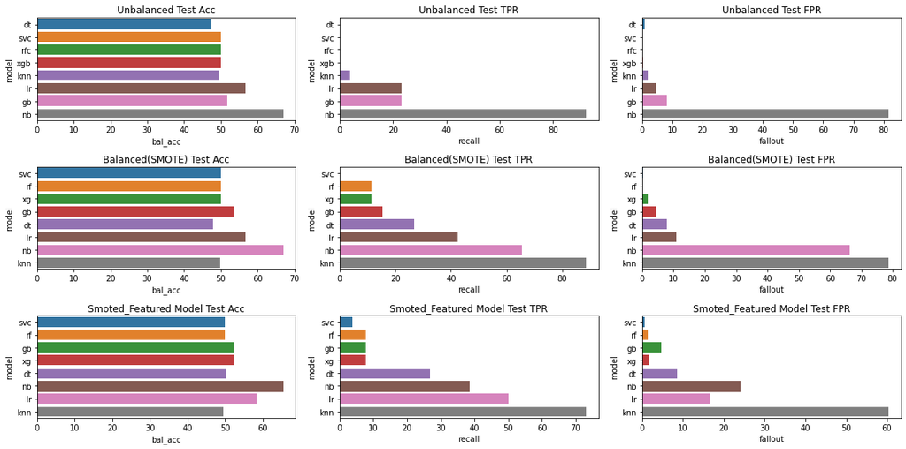

```python
fig, ax = plt.subplots(3,3, figsize=(16, 8))
sns.barplot(x="bal_acc", y="model", data=sc_ev.sort_values(by="recall"), ax=ax[0,0])
ax[0,0].set_title("Unbalanced Test Acc")
sns.barplot(x="recall", y="model", data=sc_ev.sort_values(by="recall"), ax=ax[0,1])
ax[0,1].set_title("Unbalanced Test TPR")
sns.barplot(x="fallout", y="model", data=sc_ev.sort_values(by="recall"), ax=ax[0,2])
ax[0,2].set_title("Unbalanced Test FPR")

sns.barplot(x="bal_acc", y="model", data=sc_ev_bal.sort_values(by="recall"), ax=ax[1,0])
ax[1,0].set_title("Balanced(SMOTE) Test Acc")
sns.barplot(x="recall", y="model", data=sc_ev_bal.sort_values(by="recall"), ax=ax[1,1])
ax[1,1].set_title("Balanced(SMOTE) Test TPR")
sns.barplot(x="fallout", y="model", data=sc_ev_bal.sort_values(by="recall"), ax=ax[1,2])
ax[1,2].set_title("Balanced(SMOTE) Test FPR")

sns.barplot(x="bal_acc", y="model", data=sc_eval_smote_fe.sort_values(by="recall"), ax=ax[2,0])
ax[2,0].set_title("Smoted_Featured Model Test Acc")
sns.barplot(x="recall", y="model", data=sc_eval_smote_fe.sort_values(by="recall"), ax=ax[2,1])
ax[2,1].set_title("Smoted_Featured Model Test TPR")
sns.barplot(x="fallout", y="model", data=sc_eval_smote_fe.sort_values(by="recall"), ax=ax[2,2])
ax[2,2].set_title("Smoted_Featured Model Test FPR")

plt.tight_layout()
plt.show()
```